# s05 — heterogeneous divergence (chr19, SNP-only, continuous autocorrelated field)

gwct

10/28/2026 10:34 EDT

```r
knitr::opts_chunk$set(echo = TRUE, warning = FALSE, message = FALSE, fig.align = "center")
library(ggplot2); library(dplyr); library(tidyr); library(readr)
source("analyses/lib/design.r")   # bartheme(), corecol(); knit from the project root
```

**Provenance**

- **Rendered from commit** `12452f63e370` (branch `mason2-sims`) on 2026-10-28 10:34
- **This notebook:** notebook as committed
- **Analysis code:** no uncommitted edits under `analyses/`
- Each data file’s producing script and command: the section’s `MANIFEST.yaml`

# 1 Question & design

**Real divergence is not spread evenly along the genome** — it clusters (fast/ “accelerated-like” patches) and thins (conserved-like stretches) at the scale of features, genes, and recombination structure. If the *same amount* of divergence is concentrated instead of uniform, **how much does read mapping and SNP recovery change, and can iterative mapping recover the diverged patches?**

The trick that makes this a clean experiment: the **genome-wide mean divergence is held fixed at D = 0.06** for every configuration. Only the *spatial structure* varies. So any difference from the homogeneous baseline is due to structure, not amount — and the σ = 0 configuration reproduces uniform placement exactly and serves as the in-section control (it is the s01-style homogeneous run at D = 0.06).

Everything below is **chr19, SNP-only, 30×**, produced by `workflow.smk` and driven by `config/config.yaml` (`run_sweep.sh`). It is identical to the s01 pipeline except for how divergent sites are placed.

- **The divergence field** (`analyses/lib/divergence_field.py`): a latent Gaussian field is built as white noise smoothed by an FFT Gaussian kernel of standard deviation **corr_len** (the correlation length = scale of heterogeneity), standardized, then turned into placement weights `w(x) = exp(σ · z(x))` (σ = amplitude). Exactly `round(D·L)` divergent sites are drawn **without replacement, ∝ w(x)** (Efraimidis– Spirakis). Because the count is fixed, **the mean divergence is pinned by construction** — the field only redistributes. Two knobs: **corr_len** (2 kb / 20 kb / 200 kb) and **σ** (0 / 1 / 2). The realized 1/e autocorrelation length is ≈ 2 × corr_len (a documented property of Gaussian smoothing). Het sites and (here, zero) indels stay **uniform** — only fixed divergence is made heterogeneous.
- **Configurations** (field tag `L{corr_len}-S{σ}`, `field_seed = 42` fixes *which* regions are hot): `L20000-S0.0` (homogeneous control), `L2000-S1.0`, `L20000-S1.0`, `L200000-S1.0`, `L20000-S2.0`.
- **Truth** (`make_truth_vcf.py --divergence-sigma/-corr-len/-field-seed`): homozygous divergence SNPs at mean **D = 0.06** (`1|1`), heterozygous SNPs at **H = 0.005** (`0|1`, uniform), **no indels**. Alt alleles uniform over the 3 non-reference bases.
- **Reads / mapping / iteration / callers / scoring:** identical to s01 — `mason_simulator` 30× 150 bp / 300 bp fragments (seed 42); `bwa mem`; **3 iterations** (iter 1 = single-shot, iter *k* maps to the iter *k−1* homozygous-SNP consensus, reference-length → no liftover); **gatk / bcftools / freebayes**; recovery = cumulative consensus-vs-reference SNP diff vs truth (`compare_vcfs.py`, `div_tp`).
- **Local divergence** (`annotate_local_divergence.py`): every divergent truth site is labeled with its **measured local divergence** = divergent-site density in a **±150 bp (read)** and **±500 bp (fragment)** window — the divergence a read covering it actually experiences. This is the binning axis for the recovery analysis. Note: averaged over *sites*, local divergence exceeds the global mean because divergent sites preferentially sit in dense regions (size-biasing) — the genome mean is still pinned; binning uses the per-site value.

**Single seed (42).** s01 showed aggregate recall over chr19’s millions of sites is near-deterministic across seeds (SD ~0), so one seed suffices for the mean; replicate seeds would only add negligible error bars.

```r
labs <- c(`L20000-S0.0` = "homogeneous (σ=0)",
          `L2000-S1.0`  = "σ=1, ℓ=2kb",
          `L20000-S1.0` = "σ=1, ℓ=20kb",
          `L200000-S1.0`= "σ=1, ℓ=200kb",
          `L20000-S2.0` = "σ=2, ℓ=20kb")
lev <- names(labs)
mkfac <- function(x) factor(labs[x], levels = labs[lev])
callers <- c("gatk", "bcftools", "freebayes")

# global recovery (mean D fixed; `field` column distinguishes configs)
g <- read_csv("analyses/s05-heterogeneous-divergence/results/s05-hetdiv-iterative-summary.csv") %>%
  mutate(recall    = div_tp / n_truth_div,
         precision = ifelse(n_called_snp > 0, 1 - fp / n_called_snp, NA),
         caller    = factor(caller, levels = callers),
         iteration = factor(iteration),
         config    = mkfac(field))

# recall binned by local divergence
lr <- read_csv("analyses/s05-heterogeneous-divergence/results/s05-local-recall.csv") %>%
  mutate(caller = factor(caller, levels = callers), iteration = factor(iteration),
         config = mkfac(field))
lr_bin <- lr %>% filter(window == 150, locald_mid != "")     # binned rows, read scale
lr_bin$locald_mid <- as.numeric(lr_bin$locald_mid)

# landscape + local-D distribution
land <- read_csv("analyses/s05-heterogeneous-divergence/results/s05-landscape.csv") %>%
  filter(valid == 1) %>% mutate(config = mkfac(field))
dist <- read_csv("analyses/s05-heterogeneous-divergence/results/s05-localdist.csv") %>%
  filter(window == 150, !grepl(">", locald_mid)) %>%
  mutate(locald_mid = as.numeric(locald_mid), config = mkfac(field))

cols_it  <- corecol(pal = "wilke", numcol = 3)              # 3 iterations
cols_cfg <- corecol(pal = "wilke", numcol = 5)              # 5 configs
```

# 2 The divergence landscape

The two knobs produce landscapes ranging from flat (the control) to sharply spiked. The panels below show local divergence (divergent sites per mappable base, 50 kb bins) along chr19. The **homogeneous control is flat at ≈ 0.06**; raising σ deepens the peaks and troughs; changing the correlation length changes how *wide* the hot/cold runs are (short ℓ = fine texture, long ℓ = broad blocks). The dashed line is the fixed mean D = 0.06 that **all** panels share.

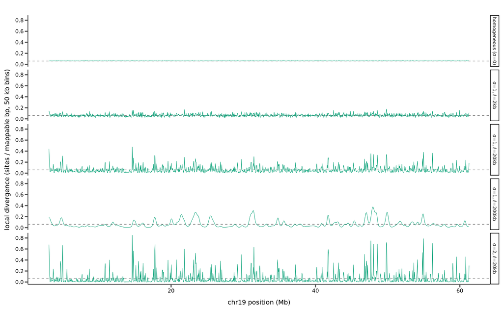

```r
ggplot(land, aes(bin_center/1e6, local_divergence)) +
  geom_hline(yintercept = 0.06, linetype = "dashed", color = "grey50") +
  geom_line(color = cols_cfg[3], linewidth = 0.3) +
  facet_wrap(~config, ncol = 1, strip.position = "right") +
  labs(x = "chr19 position (Mb)", y = "local divergence (sites / mappable bp, 50 kb bins)") +
  bartheme()
```

*Interpretation.* Same mean, very different genomes as a read sees them. Under σ = 1 the local divergence swings from near 0 to ~0.2–0.3 over the chromosome; under σ = 2 the peaks exceed 0.4. Correlation length sets the width of those excursions — `ℓ=2kb` is finely mottled, `ℓ=200kb` is a few broad blocks — while keeping the same genome-wide average. N-gap bins (<50 % mappable) are dropped.

## 2.1 How heterogeneity spreads the divergence a read experiences

The same information per *site*: the distribution of local divergence at the read (±150 bp) scale. The control is a narrow spike near the mean; heterogeneity spreads a large fraction of sites into high–local-divergence territory where mapping fails.

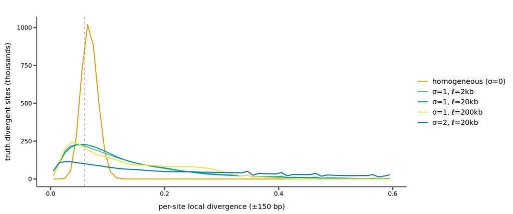

```r
ggplot(dist, aes(locald_mid, n_sites/1e3, color = config)) +
  geom_vline(xintercept = 0.06, linetype = "dashed", color = "grey50") +
  geom_line(linewidth = 0.8) +
  scale_color_manual(values = cols_cfg, name = NULL) +
  labs(x = "per-site local divergence (±150 bp)", y = "truth divergent sites (thousands)") +
  bartheme() + theme(legend.position = "right")
```

```r
hi <- dist %>% group_by(config) %>%
  summarize(`% sites, localD>0.15` = round(100*sum(n_sites[locald_mid>0.15])/sum(n_sites),1),
            `% sites, localD>0.25` = round(100*sum(n_sites[locald_mid>0.25])/sum(n_sites),1),
            .groups="drop")
knitr::kable(hi, caption="Fraction of divergent sites sitting in high–local-divergence neighborhoods.")
```

Fraction of divergent sites sitting in high–local-divergence neighborhoods.

| config | % sites, localD>0.15 | % sites, localD>0.25 |
| --- | --- | --- |
| homogeneous (σ=0) | 0.0 | 0.0 |
| σ=1, ℓ=2kb | 34.1 | 14.6 |
| σ=1, ℓ=20kb | 32.6 | 12.9 |
| σ=1, ℓ=200kb | 38.5 | 15.3 |
| σ=2, ℓ=20kb | 55.6 | 38.1 |

# 3 Recovery is governed by *local* divergence

Binning each divergent site by its local divergence and asking what fraction was recovered turns the aggregate into a mechanism. Below, the reference configuration (σ = 1, ℓ = 20 kb); lines are iterations.

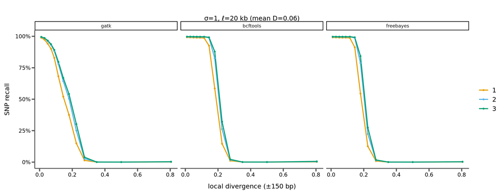

```r
ref <- lr_bin %>% filter(field == "L20000-S1.0")
ggplot(ref, aes(locald_mid, recall, color = iteration)) +
  geom_line(linewidth = 0.9) + geom_point(size = 1) +
  scale_color_manual(values = cols_it, name = "iteration") +
  scale_y_continuous(labels = scales::percent) +
  facet_wrap(~caller, nrow = 1) +
  labs(x = "local divergence (±150 bp)", y = "SNP recall",
       title = "σ=1, ℓ=20 kb (mean D=0.06)") +
  bartheme() + theme(legend.position = "right")
```

*Interpretation.* Two distinct failure shapes. **gatk erodes gradually** — its reference-anchored reassembler starts losing sites from local divergence ~0.06 upward. **bcftools and freebayes hold a ~99.7 % plateau** until ~0.13–0.15 local divergence, then **fall off a cliff**. Above local divergence ~0.25 *all three* callers recover essentially nothing, even at iteration 3: these are the diverged cores where reads no longer map. **Iteration lifts the curves** (most for gatk, in the gradual-erosion zone) but **cannot rescue the cores** — the cliff moves only slightly.

## 3.1 The same curves across configurations

Overlaying iter-3 recall-vs-local-divergence for all configs shows something important: at **matched local divergence the curves nearly coincide**. The correlation length and amplitude barely change *how recoverable a given local divergence is* — what they change is **how many sites land at each local divergence** (previous section).

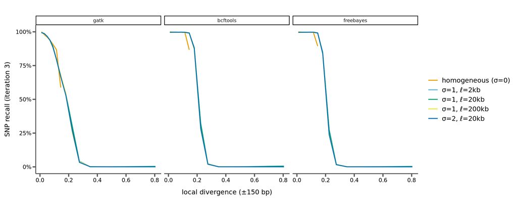

```r
i3 <- lr_bin %>% filter(iteration == 3)
ggplot(i3, aes(locald_mid, recall, color = config)) +
  geom_line(linewidth = 0.8) +
  scale_color_manual(values = cols_cfg, name = NULL) +
  scale_y_continuous(labels = scales::percent) +
  facet_wrap(~caller, nrow = 1) +
  labs(x = "local divergence (±150 bp)", y = "SNP recall (iteration 3)") +
  bartheme() + theme(legend.position = "right")
```

*Interpretation.* The recovery-vs-local-divergence relationship is close to a **property of the mapper/caller**, not of the landscape: a site at local divergence 0.2 recovers about the same whether it sits in a 2 kb patch or a 200 kb block. The one systematic gap is at the transition, where **`ℓ=200kb` recovers slightly *worse* at matched local divergence** — the anchoring/spillover effect (below).

# 4 Why recovery fails: mapping vs. calling

The recall curves above *describe* the wall; this section says **what breaks at it**. Reference bias is really two distinct failures, and they have different cures:

- **mapping-limited** — the alt-carrying reads never arrive at the site (they soft-clip over it, mismap elsewhere, or don’t map at all), so the alt allele is **absent from the pileup** and *no* caller could emit it; versus
- **calling-limited** — the alt allele **is present** in the pileup with real read support, but the caller does not emit the variant (an assembler/genotyper failure).

Using the per-site read-fate ledger + position pileup (`variant_read_fate.py --pileup`, truth alignment regenerated deterministically; 50 k sampled sites on the reference config L20000-S1.0), every unrecovered divergent site is classed as one or the other: unrecovered with ≥ 2 alt reads in the pileup = calling-limited, else mapping-limited. The stacked bands below sum to 1 in each local-divergence bin.

```r
mvc <- read_csv("analyses/s05-heterogeneous-divergence/results/s05-mapping-vs-calling.csv") %>%
  filter(window == 150, iteration %in% c(1,3), n_sites > 50, locald_mid <= 0.5) %>%
  mutate(caller = factor(caller, levels = callers),
         iteration = factor(paste0("iteration ", iteration)))
mvc_long <- mvc %>%
  select(caller, iteration, locald_mid, frac_recovered, frac_calling, frac_mapping) %>%
  pivot_longer(starts_with("frac_"), names_to = "class", values_to = "frac") %>%
  mutate(class = factor(recode(class,
                               frac_recovered = "recovered",
                               frac_calling   = "calling-limited",
                               frac_mapping   = "mapping-limited"),
                        levels = c("recovered", "calling-limited", "mapping-limited")))
mvc_cols <- c(recovered = "#4477AA", `calling-limited` = "#CCBB44", `mapping-limited` = "#AA3377")
```

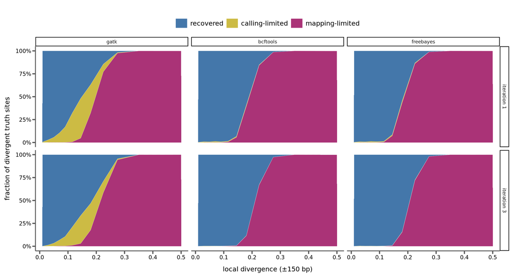

```r
ggplot(mvc_long, aes(locald_mid, frac, fill = class)) +
  geom_area(color = "white", linewidth = 0.1) +
  scale_fill_manual(values = mvc_cols, name = NULL) +
  scale_y_continuous(labels = scales::percent) +
  facet_grid(iteration ~ caller) +
  labs(x = "local divergence (±150 bp)", y = "fraction of divergent truth sites") +
  bartheme() + theme(legend.position = "top")
```

*Interpretation.* The two callers fail for **different reasons**, and this is the whole explanation of the two recall shapes:

- **bcftools / freebayes are essentially never calling-limited** (the amber band is absent). Given the alt in the pileup they always call it; their entire loss is the **mapping- limited** band appearing abruptly at local divergence ~0.15 — i.e. their cliff *is* the alt reads clipping/mismapping out of the pileup. Corroborated by the ledger: alt-support survival (f_alt) and pileup alt-depth collapse across exactly that band (f_alt 0.82→0.05, ~26→1 alt reads from local D 0.115→0.225).
- **gatk adds a calling-limited deficit** (a wide amber band from local divergence ~0.05): its reassembler fails to emit variants that *are* present in the pileup (f_alt still 0.6– 0.9, 19–29 alt reads). That extra band is exactly why gatk sits below the pileup callers throughout the recoverable range. Past ~0.18 gatk also enters the mapping-limited regime.
- **The wall (local divergence ≳ 0.25) is mapping-limited for all three** — reads carrying the alt stop arriving entirely (f_alt→0), so it is a property of the aligner, not the caller. This is why the callers converge to ~0 together.

**Iteration acts on both failures.** From iteration 1 → 3 the mapping-limited band shrinks (the consensus absorbs recovered divergence, lowering *effective* local divergence, so more alt reads place — e.g. bcftools at local D 0.18: recall 0.59 → 0.88, mapping-limited 0.40 → 0.12), and for gatk the calling-limited band shrinks too (the improved consensus also makes the reassembly tractable). What iteration cannot move is the high–local-divergence core, which stays mapping-limited at every iteration — the reads never map there to begin with.

# 5 Heterogeneity vs. the homogeneous control, at fixed mean

Same mean divergence, drastically different recovery. The bars compare each config’s global recall to the homogeneous control.

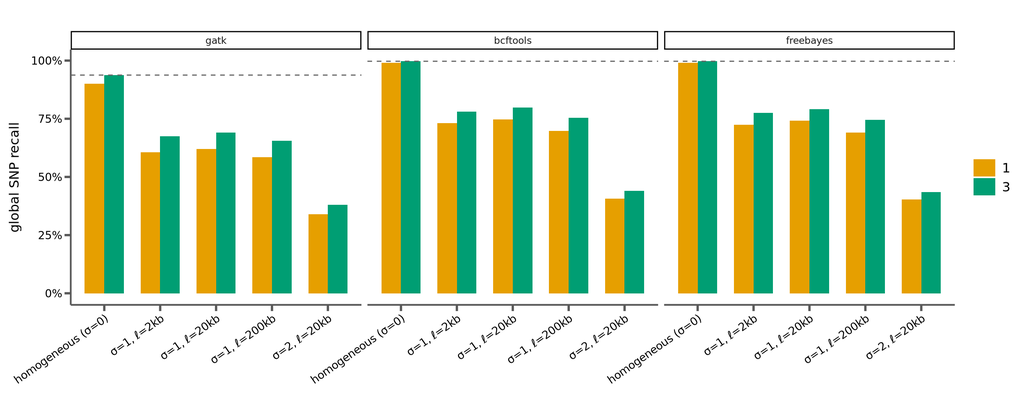

```r
gg <- g %>% filter(iteration %in% c("1","3"))
ggplot(gg, aes(config, recall, fill = iteration)) +
  geom_col(position = "dodge", width = 0.7) +
  geom_hline(data = g %>% filter(field=="L20000-S0.0", iteration=="3"),
             aes(yintercept = recall), linetype = "dashed", color = "grey40") +
  scale_fill_manual(values = cols_it[c(1,3)], name = "iteration") +
  scale_y_continuous(labels = scales::percent) +
  facet_wrap(~caller, nrow = 1) +
  labs(x = NULL, y = "global SNP recall") +
  bartheme() + theme(axis.text.x = element_text(angle = 35, hjust = 1))
```

```r
gt <- g %>% filter(iteration %in% c("1","3")) %>%
  select(config, caller, iteration, recall) %>%
  pivot_wider(names_from = iteration, values_from = recall, names_prefix = "iter") %>%
  mutate(across(c(iter1, iter3), ~round(100*.,1))) %>%
  arrange(caller, config)
knitr::kable(gt, caption = "Global SNP recall (%), iteration 1 vs 3. Dashed line in the figure = the homogeneous control's iter-3 recall.")
```

Global SNP recall (%), iteration 1 vs 3. Dashed line in the figure = the homogeneous control’s iter-3 recall.

| config | caller | iter1 | iter3 |
| --- | --- | --- | --- |
| homogeneous (σ=0) | gatk | 90.0 | 93.8 |
| σ=1, ℓ=2kb | gatk | 60.6 | 67.5 |
| σ=1, ℓ=20kb | gatk | 62.0 | 69.1 |
| σ=1, ℓ=200kb | gatk | 58.5 | 65.5 |
| σ=2, ℓ=20kb | gatk | 34.0 | 38.1 |
| homogeneous (σ=0) | bcftools | 99.1 | 99.7 |
| σ=1, ℓ=2kb | bcftools | 73.1 | 78.1 |
| σ=1, ℓ=20kb | bcftools | 74.8 | 79.9 |
| σ=1, ℓ=200kb | bcftools | 69.9 | 75.4 |
| σ=2, ℓ=20kb | bcftools | 40.7 | 44.0 |
| homogeneous (σ=0) | freebayes | 99.1 | 99.7 |
| σ=1, ℓ=2kb | freebayes | 72.4 | 77.5 |
| σ=1, ℓ=20kb | freebayes | 74.1 | 79.2 |
| σ=1, ℓ=200kb | freebayes | 69.1 | 74.6 |
| σ=2, ℓ=20kb | freebayes | 40.3 | 43.5 |

*Interpretation.* At the **same mean D = 0.06** where the homogeneous control gives bcftools/freebayes **~99.7 %**, clustering drops them to **~80 %** (σ = 1) and **~44 %** (σ = 2); gatk falls from ~94 % to ~69 % and ~38 %. **Reporting only mean divergence badly understates reference bias** whenever divergence is spatially structured — which it always is in real genomes. Iteration still helps (gatk most), but never closes the gap to the control, because the diverged cores are unrecoverable.

# 6 What drives it: amplitude, scale, and spillover

**Amplitude (σ) dominates.** Going σ = 1 → 2 roughly halves recall (e.g. bcftools 80 % → 44 %). Amplitude controls how *extreme* the hot spots get, and recovery is a steeply falling function of local divergence, so deeper spikes remove disproportionately more sites.

**Correlation length has a smaller, two-part effect.** From the sections above:

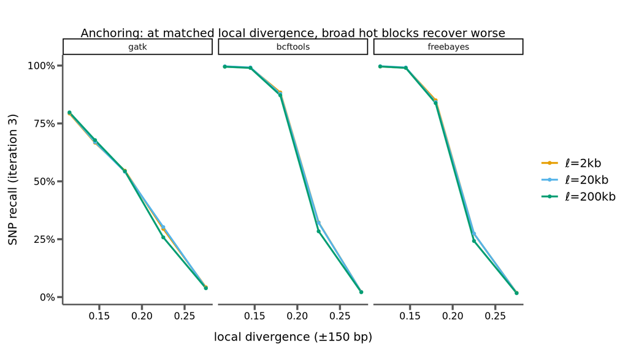

```r
sp <- lr_bin %>%
  filter(iteration == 3, sigma == 1, locald_mid > 0.10, locald_mid < 0.30) %>%
  mutate(corr = factor(paste0("ℓ=", as.integer(corr_len)/1000, "kb"),
                       levels = c("ℓ=2kb","ℓ=20kb","ℓ=200kb")))
ggplot(sp, aes(locald_mid, recall, color = corr)) +
  geom_line(linewidth = 0.9) + geom_point(size = 1.2) +
  scale_color_manual(values = corecol(pal="wilke", numcol=3), name = NULL) +
  scale_y_continuous(labels = scales::percent) +
  facet_wrap(~caller, nrow = 1) +
  labs(x = "local divergence (±150 bp)", y = "SNP recall (iteration 3)",
       title = "Anchoring: at matched local divergence, broad hot blocks recover worse") +
  bartheme() + theme(legend.position = "right")
```

*Interpretation.* The three correlation lengths nearly overlap — confirming recovery is mostly a function of local divergence, not block size — but in the transition zone `ℓ=200kb` sits a few points below `ℓ=2kb`/`ℓ=20kb`. A diverged site flanked by more diverged sequence (a big block) loses the read-anchoring help that a diverged site in a small patch still gets from its conserved surroundings. This is the boundary/spillover signal, small at chr-scale aggregate but mechanistically real.

# 7 Adding indels: is the effect still just redistribution?

Everything so far is SNP-only. Real genomes also differ by indels, which are the worst mapping case (a read spanning an unrepresented indel clips or mismaps). So the natural worry is an **interaction**: if indels *co-cluster* with SNP divergence, do hot regions become disproportionately unrecoverable — worse than their local divergence alone would predict?

To test it, indels were placed on the **same field** as the SNP divergence (`make_truth_vcf --indel-on-field`; indel divergence Di = 0.12·D, sizes 1–10 bp), at mean D = 0.06, run through the full indel-aware liftover pipeline (`workflow-indels.smk`: consensus rebuilt from the reference + accumulated recovered calls, Picard LiftoverVcf back to reference coordinates — identical to s02). Recovery (SNP and indel separately) is then binned by **local** divergence and overlaid on the **homogeneous** s02 curve (recall vs **mean** divergence). The separability null: heterogeneous recall at local divergence *x* should equal homogeneous recall at mean divergence *x*.

```r
hi <- read_csv("analyses/s05-heterogeneous-divergence/results/s05-hetindel-local-recovery.csv") %>%
  filter(iteration == 3, n_sites > 500) %>%
  mutate(caller = factor(caller, levels = callers),
         vtype  = factor(ifelse(vtype == "snp", "SNP", "indel"), levels = c("SNP", "indel")))
s02 <- read_csv("analyses/s02-indels/results/s02-indels-recovery-summary.csv") %>%
  filter(iteration == 3, divergence > 0) %>%
  mutate(caller = factor(caller, levels = callers),
         SNP = div_tp / n_truth_div, indel = indel_div_tp / n_truth_indel_div) %>%
  select(caller, divergence, SNP, indel) %>%
  pivot_longer(c(SNP, indel), names_to = "vtype", values_to = "recall") %>%
  mutate(vtype = factor(vtype, levels = c("SNP", "indel")))
ov_cols <- c(`homogeneous (vs mean D)` = "grey30",
             `heterogeneous (vs local D)` = corecol(pal = "wilke", numcol = 5)[3])
```

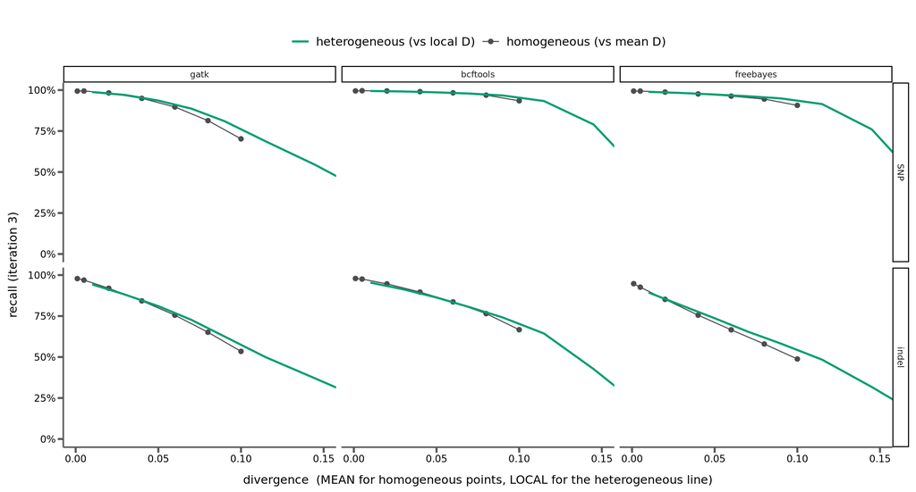

```r
ggplot() +
  geom_line(data = s02, aes(divergence, recall, color = "homogeneous (vs mean D)"),
            linewidth = 0.5) +
  geom_point(data = s02, aes(divergence, recall, color = "homogeneous (vs mean D)"),
             size = 2) +
  geom_line(data = hi, aes(locald_mid, recall, color = "heterogeneous (vs local D)"),
            linewidth = 1) +
  scale_color_manual(values = ov_cols, name = NULL) +
  scale_y_continuous(labels = scales::percent) +
  coord_cartesian(xlim = c(0, 0.15)) +
  facet_grid(vtype ~ caller) +
  labs(x = "divergence  (MEAN for homogeneous points, LOCAL for the heterogeneous line)",
       y = "recall (iteration 3)") +
  bartheme() + theme(legend.position = "top")
```

*Interpretation.* **The heterogeneous line lies on top of the homogeneous points** — for both SNPs and indels, all three callers, across the overlapping range. Recovery under clustered divergence-with-indels at local divergence *x* is the same as recovery in a homogeneous genome at mean divergence *x*. **The interaction hypothesis is refuted: there is no super-additive penalty.** (The large *global* gap — bcftools indel recall 62% here vs 84% homogeneous at the same mean — is entirely the redistribution effect: co-clustering moves a third of all sites into high-local-divergence neighborhoods where the shared curve is low.)

Why even indels are separable: because they sit on the **same field** as the SNPs, a locally-hot region has the same indel:SNP ratio as a homogeneous genome at that divergence — so it is statistically indistinguishable from “homogeneous at the local rate,” and the homogeneous curve predicts it. (An interaction would require indels to cluster *independently* of, or more tightly than, the SNPs.)

**This is the section’s most general statement.** Recovery under *any* divergence landscape is predictable from just two ingredients: the **homogeneous recall-vs-divergence curve** (a property of the mapper + caller, measured once in s01/s02) and the **local-divergence distribution** of the landscape. No new simulation is needed per landscape — heterogeneity only reshapes *where on the curve* the genome’s sites sit.

# 8 A realistic scenario

The sweep above deliberately spans a wide, partly **unrealistic** range: mean D = 0.06 is already a fairly diverged pair, and the log-normal field (especially σ = 2) drives local divergence to 0.4–0.6 — beyond substitution saturation, i.e. sequence that would not be orthologous/alignable at all. That set is best read as a **characterization of the failure curve** and a way to locate the ~25 % local-divergence *mapping wall*, not as a biological genome.

This section is the **biologically-defensible scenario**, produced by `config-realistic.yaml`:

- **lower mean divergence (D = 0.03)**,
- **moderate amplitude (σ = 1)**,
- a **cap on local divergence at 0.20** — the field’s hot regions are bounded to the realistic “fast-evolving” range instead of saturating (validated: per-site local divergence at read scale has **p95 ≈ 0.19**, and only **3.3 %** of sites exceed 0.20; uncapped, the same field reached 0.57), and
- **heterozygosity placed on the same field as divergence** (`het_on_field: true`) — so diversity co-varies with divergence, as in real genomes, rather than being uniform.

It includes its own **mean-0.03 homogeneous control**.

```r
labr <- c(`L20000-S0.0` = "homogeneous", `L20000-S1.0-C0.20` = "realistic\n(cap 0.20, het on field)")
gr <- read_csv("analyses/s05-heterogeneous-divergence/results/s05-realistic-iterative-summary.csv") %>%
  mutate(recall = div_tp / n_truth_div, caller = factor(caller, levels = callers),
         iteration = factor(iteration), config = factor(labr[field], levels = labr))
lrr <- read_csv("analyses/s05-heterogeneous-divergence/results/s05-realistic-local-recall.csv") %>%
  filter(window == 150, locald_mid != "") %>%
  mutate(caller = factor(caller, levels = callers), iteration = factor(iteration),
         locald_mid = as.numeric(locald_mid), config = factor(labr[field], levels = labr))
```

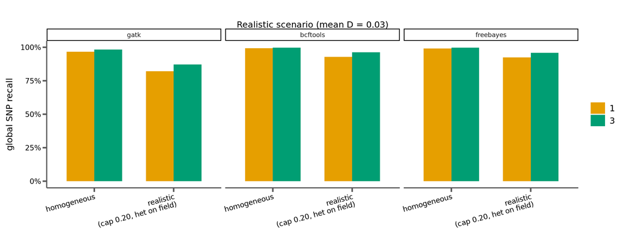

```r
ggplot(gr %>% filter(iteration %in% c("1","3")), aes(config, recall, fill = iteration)) +
  geom_col(position = "dodge", width = 0.7) +
  scale_fill_manual(values = cols_it[c(1,3)], name = "iteration") +
  scale_y_continuous(labels = scales::percent) +
  facet_wrap(~caller, nrow = 1) +
  labs(x = NULL, y = "global SNP recall", title = "Realistic scenario (mean D = 0.03)") +
  bartheme() + theme(axis.text.x = element_text(angle = 15, hjust = 1))
```

```r
grt <- gr %>% filter(iteration %in% c("1","3")) %>%
  mutate(config = gsub("\n"," ",config)) %>%
  select(config, caller, iteration, recall) %>%
  pivot_wider(names_from = iteration, values_from = recall, names_prefix = "iter") %>%
  mutate(across(c(iter1, iter3), ~round(100*.,1))) %>% arrange(caller, config)
knitr::kable(grt, caption = "Realistic scenario: global SNP recall (%), iteration 1 vs 3.")
```

Realistic scenario: global SNP recall (%), iteration 1 vs 3.

| config | caller | iter1 | iter3 |
| --- | --- | --- | --- |
| homogeneous | gatk | 96.6 | 98.2 |
| realistic (cap 0.20, het on field) | gatk | 82.1 | 87.1 |
| homogeneous | bcftools | 99.2 | 99.8 |
| realistic (cap 0.20, het on field) | bcftools | 92.9 | 96.2 |
| homogeneous | freebayes | 99.2 | 99.8 |
| realistic (cap 0.20, het on field) | freebayes | 92.5 | 95.8 |

*Interpretation.* Even this **modest, capped** heterogeneity measurably reduces recovery relative to the homogeneous control at the same mean: at iteration 3, gatk falls **98.2 % → 87.1 %** (−11 pt) and bcftools/freebayes **99.8 % → ~96 %** (−3.6 pt). The effect is real but **not catastrophic** — capping the spikes removes the collapse seen in the σ = 2 stress test. Iteration recovers a meaningful share (gatk **+5 pt**, bcftools **+3.3 pt** from iter 1 → 3). So the qualitative conclusions survive into the realistic regime: **clustered divergence costs recall even at a low mean, gatk is hit hardest, and iteration helps but does not fully close the gap.**

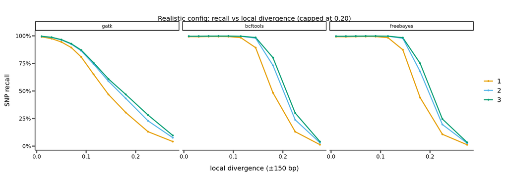

```r
ggplot(lrr %>% filter(field == "L20000-S1.0-C0.20"),
       aes(locald_mid, recall, color = iteration)) +
  geom_line(linewidth = 0.9) + geom_point(size = 1) +
  scale_color_manual(values = cols_it, name = "iteration") +
  scale_y_continuous(labels = scales::percent) +
  facet_wrap(~caller, nrow = 1) +
  labs(x = "local divergence (±150 bp)", y = "SNP recall",
       title = "Realistic config: recall vs local divergence (capped at 0.20)") +
  bartheme() + theme(legend.position = "right")
```

*Interpretation.* Same recall-vs-local-divergence shape as the characterization sweep — because it is a property of the mapper/caller — but the cap keeps the population of sites within the recoverable/transition range, so the genome-wide damage is bounded. The curve simply does not extend into the “>0.25, everything dies” regime, because the field no longer puts sites there.

## 8.1 Across mean divergence

The single realistic point becomes a curve by sweeping the genome-wide **mean** divergence at the fixed realistic settings (σ=1, ℓ=20 kb, cap 0.20, het on field) — “reference bias vs divergence, realistic,” laid against the **homogeneous** baseline (s01). We do not re-sweep σ/ℓ (the characterization already mapped those); only the mean varies, because that is the primary biological axis.

```r
ms <- read_csv("analyses/s05-heterogeneous-divergence/results/s05-realistic-meansweep-iterative-summary.csv") %>%
  filter(divergence > 0) %>%
  mutate(recall = div_tp / n_truth_div, caller = factor(caller, levels = callers),
         iteration = factor(iteration))
s01m <- read_csv("analyses/s01-baseline-iterative/results/s01-base-iterative-summary.csv") %>%
  filter(divergence > 0) %>%
  mutate(recall = div_tp / n_truth_div, caller = factor(caller, levels = callers)) %>%
  group_by(caller, divergence, iteration) %>%      # average over s01's replicate seeds
  summarize(recall = mean(recall), .groups = "drop") %>% mutate(iteration = factor(iteration))
ms_cols <- c(homogeneous = "grey35",
             `realistic heterogeneous` = corecol(pal = "wilke", numcol = 5)[1])
```

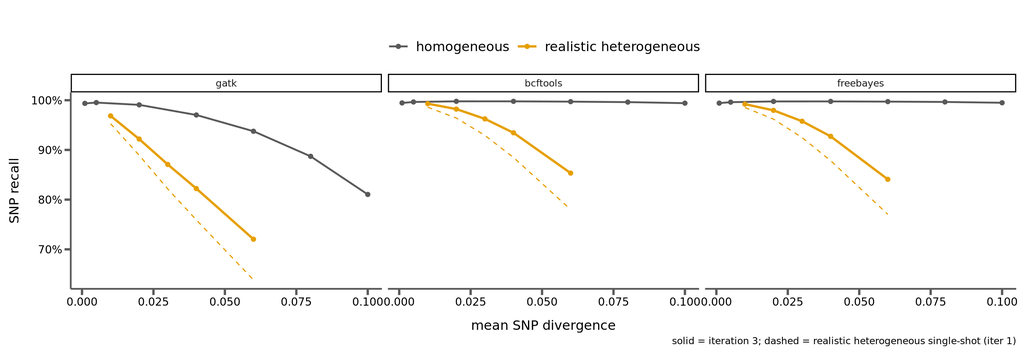

```r
ggplot() +
  geom_line(data = s01m %>% filter(iteration == 3),
            aes(divergence, recall, color = "homogeneous"), linewidth = 0.8) +
  geom_point(data = s01m %>% filter(iteration == 3),
             aes(divergence, recall, color = "homogeneous"), size = 1.6) +
  geom_line(data = ms %>% filter(iteration == 1),
            aes(divergence, recall, color = "realistic heterogeneous"),
            linewidth = 0.5, linetype = "dashed") +
  geom_line(data = ms %>% filter(iteration == 3),
            aes(divergence, recall, color = "realistic heterogeneous"), linewidth = 1) +
  geom_point(data = ms %>% filter(iteration == 3),
             aes(divergence, recall, color = "realistic heterogeneous"), size = 1.6) +
  scale_color_manual(values = ms_cols, name = NULL) +
  scale_y_continuous(labels = scales::percent) +
  facet_wrap(~caller, nrow = 1) +
  labs(x = "mean SNP divergence", y = "SNP recall",
       caption = "solid = iteration 3; dashed = realistic heterogeneous single-shot (iter 1)") +
  bartheme() + theme(legend.position = "top")
```

*Interpretation.* Reference bias grows with mean divergence, and at every mean the **realistic heterogeneous** genome loses more than the homogeneous one — the gap widening with divergence (at mean 0.06, iteration 3: bcftools ~85 % vs ~100 % homogeneous; gatk ~72 % vs ~94 %). So even a *capped, low-amplitude* landscape with correlated heterozygosity carries a real, divergence- scaling reference-bias cost that a mean-divergence-only view misses. The dashed line (single- shot) vs the solid (iterated) is the size of the fix: iteration recovers a growing share as divergence rises, most for gatk, but does not fully close the gap to the homogeneous ceiling.

# 9 Summary

- **Heterogeneity matters enormously at fixed mean.** Concentrating the same D = 0.06 into an autocorrelated field drops recall from the homogeneous ~99.7 % (bcftools/freebayes) to ~80 % (σ=1) or ~44 % (σ=2); gatk ~94 % → ~69 % / ~38 %. **Mean divergence alone is a poor predictor of reference bias.**
- **Recovery is governed by *local* divergence.** Recall is ~99.7 % up to local divergence ~0.13 (pileup callers) then cliffs; gatk erodes from ~0.06. Above ~0.25 local divergence, nothing is recovered even at iteration 3 — the diverged cores are the hard floor.
- **The wall is two different failures.** bcftools/freebayes loss is ~entirely *mapping- limited* (alt reads clip/mismap out of the pileup) — their cliff at ~0.15 is evidence vanishing, not a caller flaw. gatk adds a *calling-limited* deficit from ~0.05 (its reassembler drops variants that are present in the pileup), which is why it trails the pileup callers throughout. The ~0.25 core is mapping-limited for all three (an aligner limit). Iteration shrinks both bands — lower effective divergence → reads place and the reassembly becomes tractable — but cannot move the un-mappable core.
- **Amplitude > correlation length.** σ (how extreme the spikes) dominates; ℓ (their width) acts mainly by reshaping the local-divergence distribution, plus a small anchoring effect where broad hot blocks recover worse than small hot patches at matched local divergence.
- **The effect is separable — even with indels.** Heterogeneous recall vs *local* divergence coincides with homogeneous recall vs *mean* divergence, for SNPs and indels co-clustered on the same field. There is no super-additive interaction; heterogeneity only *redistributes* sites along the local-divergence axis. Consequence: recovery under any landscape is predictable from the homogeneous recall-vs-divergence curve plus the local-divergence distribution — no per-landscape simulation needed.
- **Iteration helps but cannot rescue the cores** — it lifts the gradual-erosion zone (gatk most), never the cliff.
- **In a realistic regime the effect is bounded but persists.** At mean D = 0.03 with capped local divergence (≤0.20) and heterozygosity on the same field, recall still drops vs the homogeneous control — gatk −11 pt, pileup callers −3.6 pt at iteration 3 — and iteration recovers only part of it. So the finding is not an artifact of the extreme stress-test settings.
- **General reference-bias implication.** The high–local-divergence tail is where recovery collapses, so *any* downstream analysis that leans on the diverged / fast-evolving regions of a genome is preferentially starved of exactly the sequence it needs, and iteration only partially restores it. “Accelerated” / “conserved” here are just the high / low tails of the continuous local-divergence axis (a post-hoc reading of the field, no labeled classes injected). PhyloAcc-style acceleration detection is one such downstream consumer, not the point of the analysis.

*Data tables (with dictionaries) in `results/`: `s05-hetdiv-iterative-summary.csv` (global recovery), `s05-local-recall.csv` (recall by local divergence), `s05-landscape.csv` + `s05-localdist.csv` (the landscapes). Fixed local-divergence bin edges are recorded in the `s05-local-recall.csv` dictionary.*